# Lab2

David Wilson • dwils152@uncc.edu

2/3/2022

## Problem 1

### a) You walk into the “occasionally dishonest casino” with prior probabilities and likelihoods that a “loaded” die has a 10% chance of getting a 1-5 and a 50% chance of getting a 6 but 99% of the dice are fair)

#### You pick up one die and with it roll: 2 3 2 6 3 5 6 2 6 6 2 6 6 2 3 6 6 6 5 6 6 5 6 6 6 6 6 4 6 3 3 3 6 6 5 6 6

#### Make a graph of the posterior probability that you have picked up a loaded die as a function of the number of times you have rolled the die.

```r
#Calculating the posterior probabilities from the observed data
rolls <- c(2,3,2,6,3,5,6,2,6,6,2,6,6,2,3,6,6,6,5,6,6,5,6,6,6,6,6,4,6,3,3,3,6,6,5,6,6)

prob_loaded <- 0.01
loaded_likelihoods <- c(rep(0.1, 5), 0.5)
fair_likelihoods <- rep(0.165, 6)

posteriors <- vector(length=length(rolls))

for ( i in 1:length(rolls) ) {

  posterior <- loaded_likelihoods[rolls[i]] * prob_loaded /
    ( (fair_likelihoods[rolls[i]] * (1-prob_loaded)) + ((loaded_likelihoods[rolls[i]]) * prob_loaded) )

  posteriors[i] <- posterior
  prob_loaded <- posterior

}
#posteriors
```

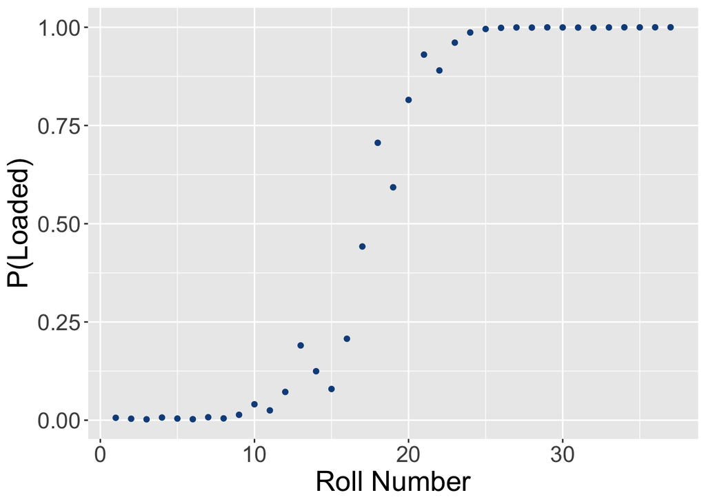

```r
#Plotting the probability that the die is loaded
library(ggplot2)
df <- data.frame(posteriors, 1:length(posteriors))
names(df) <- c("posteriors", "roll_num")
ggplot(df, aes(x=roll_num, y=posteriors)) + geom_point(color='dodgerblue4') + xlab("Roll Number") + ylab("P(Loaded)") + theme(text= element_text(size=20))
```

### b) How many times on average would you need to roll a loaded die to be 99.999% sure that it was loaded? (Show your work)

```r
#The loaded die function from Homework 1
rollLoadedDie <- function(num_rolls) {

  posterior <- loaded_likelihoods[rolls[i]] * prob_loaded /
    ( (fair_likelihoods[rolls[i]] * (1-prob_loaded)) + ((loaded_likelihoods[rolls[i]]) * prob_loaded) )

  posteriors[i] <- posterior
  prob_loaded <- posterior

  die <- c(1, 2, 3, 4, 5, 6)
  return(sample(die, size=num_rolls, replace=T, prob=c(0.1, 0.1, 0.1, 0.1, 0.1, 0.5)))

}
```

```r
#Rolling the die until we are pretty sure it's loaded
run_trial <- function() {

  iters <- 0

  while ( prob_loaded < thresh ) {

    roll <- rollLoadedDie(1)
    posterior <- loaded_likelihoods[roll] * prob_loaded /
      ( (fair_likelihoods[roll] * (1-prob_loaded)) + ((loaded_likelihoods[roll]) * prob_loaded) )
    prob_loaded <- posterior
    iters <- iters + 1

  }

  return(iters)

}
```

```r
#Running several trials and calculating the average number of rolls it takes to be 99.999% sure it's loaded

prob_loaded <- 0.01
loaded_likelihoods <- c(rep(0.1, 5), 0.5)
fair_likelihoods <- rep(0.165, 6)

thresh <- 0.99999
trial_size <- 10000
iters_list <- vector(length=trial_size)

for ( i in 1:trial_size) {

  iters_list[i] <- run_trial()

}

sum(iters_list)/length(iters_list)
```

```
## [1] 54.5827
```

## Problem 2

### You are consulting for a hospital. They have a diagnostic test for a disease with a known background prevalence of 0.1%. The test has the following properties:

> $P(\, positive\, result\, | \,person\, has\, disease) = 0.91$  
> $P(\, negative\, result\, | \,person\, does\, not\, have\, disease) = 0.84$

> The cost of running the test one time is $1. The test can be repeated for each patient and the results of the test are independent of one another allowing for Bayesian updates. The test always yields a positive or negative result.

> The requirement of the hospital is that the test is repeated for each patient until a Bayesian posterior of at least 0.99999 is reached.

### The patient has the disease but we don’t know that. what distribution do we create data from?

To generate the test data we can use the Uniform Distribution. Given the nature of our test, we know that for a patient with the disease, P(+|D) = 0.91 and P(-|D) = 0.09. If our randomly generated number is less than or equal to 0.91 we will consider it a positive test result, otherwise we will consider it a negative test result. The same concept can be applied for healthy patients… P(-|H) = 0.84 and P(+|H) = 0.16

### (a) Run simulations for a patient with the disease. About how many times on average must the test be repeated to achieve the hospital’s requirements?*

```r
#This function generates test data for a diseased individual
get_test_data <- function(num_tests, healthy) {

  tests <- vector(length=num_tests)

  for (i in 1:num_tests ) {

    if ( healthy == FALSE) {
      test <- ifelse( runif(1) <= 0.91, "Pos", "Neg")
    } else {
      test <- ifelse( runif(1) <= 0.16, "Pos", "Neg")
    }

    tests[i] <- test

  }

  return(tests)

}
```

```r
#Test a single patient until we are 99.999% sure that they are either positive or negative
test_single_patient <- function(healthy_patient) {

  pos_given_d <- 0.91
  neg_given_h <- 0.84
  prob_diseased <- 0.001
  prob_healthy <- 0.999

  posts <- vector()
  iters <- 0

  if ( healthy_patient == FALSE ) {

    while (prob_diseased <= 0.99999 ) {

      test <- get_test_data(1, healthy_patient)

      if ( test == "Pos" ) {
        post <- (pos_given_d * prob_diseased) /
          ((pos_given_d * prob_diseased) + ((1-neg_given_h) * (1-prob_diseased)))
      }
      if ( test == "Neg" ) {
        post <- ((1-pos_given_d) * prob_diseased) /
          (((1-pos_given_d) * prob_diseased) + (neg_given_h * (1-prob_diseased)))
      }
      prob_diseased <- post
      posts[iters+1] <- post
      iters <- iters + 1
    }

  } else {

      while (prob_healthy <= 0.99999 ) {

        test <- get_test_data(1, healthy_patient)

        if ( test == "Pos" ) {
          post <- ((1-neg_given_h) * prob_healthy) /
            (((1-neg_given_h) * prob_healthy) + (pos_given_d * (1-prob_healthy)))
        }
        if ( test == "Neg" ) {
          post <- (neg_given_h * prob_healthy) /
            ((neg_given_h * prob_healthy) + ((1-pos_given_d) * (1-prob_healthy)))
        }
        prob_healthy <- post
        posts[iters+1] <- post
        iters <- iters + 1
      }
  }
  return(posts)
}
```

```r
#Test many patients and average the results
num_trials <- 100000
iters_list = vector(length=num_trials)

for (i in 1:num_trials) {

  iters_list[i] <- length(test_single_patient(healthy=FALSE))

}

sum(iters_list)/length(iters_list)
```

```
## [1] 13.84781
```

#### (b) *Repeat the simulations for a patient without the disease. About how many times on average must the test be repeated to achieve the hospital’s requirements?*

```r
#This function generates test data for sick or healthy individuals
iters_list = vector(length=num_trials)

for (i in 1:num_trials) {

  iters_list[i] <- length(test_single_patient(healthy=TRUE))

}

sum(iters_list)/length(iters_list)
```

```
## [1] 3.80211
```

#### (c) *The hospital plans to run the test on one million patients per year. At a cost of $1 per test, about how much should the hospital budget to run these tests? (That is to say, for a million patients, how many tests can the hospital anticipate running?)*

```r
#drawing patients from the population based on the background rate
draw_pat <- function(num_pats) {

  pats <- runif(num_pats)

  pats <- pats <= 0.999

  return(pats)

}
```

```r
#Calculating the expense for 1 million patients
patients <- draw_pat(1000000)

total_expense <- 0

for ( i in 1:length(patients) ) {

  total_expense <- total_expense + length(test_single_patient(patients[i]))
}

total_expense
```

```
## [1] 3809577
```